# Phy 481 - HW 8

## Question 1: Hydrogen

1. Using $\frac{\alpha}{4\pi\epsilon_0} = 0.667\times10^{-30} m^3$ and $\alpha = 4\pi \epsilon_0 a^3$, we have

$$ a^3 = 0.667e-30 \\ a = \sqrt[3]{0.667e-30} = 8.7\times 10^{-11}m $$ Thus $a >a_0 = 5.3e-11$, it's a bit bigger than the Bohr radius.

2. $E = \frac{V}{d} = \frac{100V}{0.001m} = 100,000 V/m$

3. Using ionization for $d=a$ and $d$ scales linearly with $E$, we can scale up $E_0 = 100kV/m$ to $E_1$

$$ E_0*x = E_1\\ 1 = 5.25e-7 *x\\ x = \frac{1}{5.25e-7} \\ E_1 = \frac{100000}{5.25e-7} = 1.9e11\ V/m $$ aka a lot. The strongest voltage ever stored was at oakridge using an electrostatic machine, and that got up to 32 million volts (32e6). While that's not quite the same as electric field, our 1mm capacitor still wouldn't work even if it had this voltage stored across it's plates.

## Polarized sphere

1. $$ \vec P = P_0 \vec r = P_0 r \hat r \\ \sigma_b = \vec P \cdot \hat n = \left. P_0 r (\hat r \cdot \hat r)\right|_{r=a} = P_0 a \\ \rho_b = - \nabla\cdot\vec P = -\frac{1}{r^2} \frac{d}{dr}P_0r^3 = -3P_0 $$ Both values are independent of our coordinates, so our integrals are quite easy
2. First $r<a$

$$ E*4\pi r^2 = \frac{-3P_0}{\epsilon_0} \int_V dV = \frac{-4\pi r^3}{\epsilon_0} \\ E(r) = -\frac{P_0}{\epsilon_0}\vec r $$

Next: $r>a$. We'll show there's no charge

$$ Q = \int_V \rho_b dV + \int_S \sigma_b da = -4P_0\pi a^3 + P_0 a*4\pi a^2 = 0\\ E = 0 $$

The electric field points entirely inward.

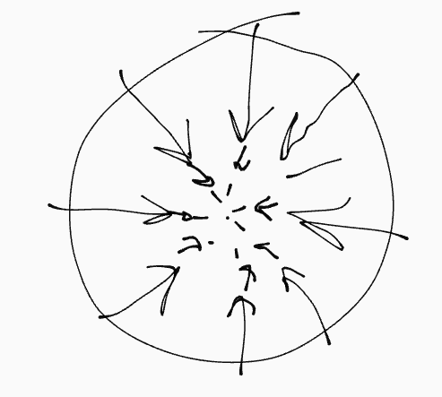

## Cylinder #1

1. $$ \vec P = k s \hat s \\ \sigma_b = ka \\ \rho_b = -\nabla \cdot \vec P = -\frac{1}{s} \frac{d}{ds} ks^2 = -2k $$ Again, these are constant. We know $[P]=\frac{C}{m^2}$, so

$$ \text{[P]} = ks = \text{[k][m]} \rightarrow \text{[k]} = \frac{C}{m^2} \\ \text{[}\sigma_b\text{]} = \text{[k][a]} = \frac{C}{m^2} \\ \text{[}\rho_b\text{]} = \text{[k]} = \frac{C}{m^3} $$

2. s<a $$ E*2\pi sL = \frac{2k}{\epsilon_0} \int_V dV \\ E = \frac{-2k \pi s^2 L}{\epsilon_0 *2\pi s L} = -\frac{ks}{\epsilon_0} \\ \vec E = -\frac{k}{\epsilon_0} \vec s $$ s>a, using gauss's law. Remember our densities are independent of coordinates (aside from the s=a boundary)

$$ \epsilon_0 E * 2\pi s L = \rho_b \pi a^2 L + \sigma_b 2\pi a L \\ = -2k\pi a^2 L + 2k\pi a^2L = 0\\ \vec E = 0 $$

3. Using $\vec D = \epsilon_0 E + \vec P$ where $\vec D=0$ since there is no free charge (gauss's law for $D$)

Inside: $$ \epsilon_0 \vec E + k \vec s = 0 \\ \vec E = -\frac{k}{\epsilon_0} \vec s \checkmark $$

Outside: No $\vec P$ means no $\vec E\checkmark$

Since we recover the same answers, gauss's law for $D$ is verified.

## Cylinder #2

$\vec P = k \hat s$

$$ \sigma_{b(a)} = k \hat s \cdot \hat s=k\\ \sigma_{b(b)} = k \hat s \cdot -\hat s = -k\\ \rho_b = -\nabla \cdot \vec P = -\frac{1}{s} \frac{d}{ds} ks = -\frac{k}{s} $$ Unfortunately, our integral trick won't work for $\rho_b$

2. s<b I wish we could just use $D$. Wait, we don't need to!

$$ E*2\pi sL = Q/\epsilon_0 = 0\\ E=0 $$ b<s<a $$ \epsilon_0E*2\pi s L = \int_V \rho_b dV - k2\pi b L \\ \int_V \rho_b dV = -k2\pi L \int_b^s \frac{1}{s} ds = -k2\pi L (s-b) \\ E=\frac{-2\pi k L s}{\epsilon_0 2\pi s L} = -\frac{k}{\epsilon_0}\\ \vec E = -\frac{k}{\epsilon_0}\hat s $$

$$ \epsilon_0 E * 2\pi sL = -2\pi k La + \int\sigma_{b(a)} dA\\ = -2\pi k La + 2\pi k La = 0\\ E=0 $$

3. Again, we have $\vec D =0$ for the same reason as in the previous problem.

s<b all zero $\checkmark$ b<s<a $\vec P = k\hat s$ $$ \vec E = -\frac{\vec P}{\epsilon_0} = -\frac{k}{\epsilon_0} \hat s \checkmark $$ s>a again all zero

So yes, this is much faster